# Case study: How Does a Bike-share Navigate Speedy Success?

#### Part of Google Data Analytic Certificate's course capstone

Author: Muftah Afrizal Pangestu  
Last updated: 9 April 2022

## Identifying Business Tasks

Cyclistic, a bike-sharing company handles two type of customers: casual customers who bought single-ride or daily passes, and Cyclistic members who bought the annual pass. The stakeholder believes that maximizing the number of Cyclistic member is the key of the company's growth as annual pass are deemed more profitable. The first step of the marketing strategy targetted toward the casual customer is to understand how the casual and member riders differ, especially in how they use the service.

[figure not shown]

As a data analyst, my tasks would be: analyse the difference of riding habit between casual and member riders and create a recommendation for the stakeholder based on it. This habit may include: the duration and distance of a ride and type of service used.

## Preparing Data for Analysis

In this step, I will be giving some background information of the data that will be used, load the data for analysis and preparing it for further transformation and cleaning in the next step of analysis.

I will be using Divvy's public data that is made available by Lyft Bikes and Scooters, LLC ("Bikeshare") and City of Chicago under this [license](https://ride.divvybikes.com/data-license-agreement) and can be accessed [here](https://divvy-tripdata.s3.amazonaws.com/index.html).

#### How reliable is this data?

The data we will be using is gathered directly by City of Chicago's Divvy bicycle sharing service and published freely as part of their commitment to supporting bicycling as an alternative transportation option. In my case, Cyclistic is an imaginary company so for this case study, we will be treating Divvy's data as Cyclistic's own data. Thus, we can consider the data we will be using is a first-party data which is the most reliable kind of data.

```python
# Importing necessary library to load the data
import pandas as pd
import glob
```

Divvy's monthly data is downloaded and stored in a folder: datasource.  
For this case study, I will be analysing data from April 2021 to March 2022.  
Data is stored in comma-separated-values (csv) format and this code below is to get the filename of every single csv files within datasource folder.

```python
path = r'datasource'
all_files = glob.glob(path + "/*.csv")
```

After getting the filename for our csv files, I proceed with loading every single of it as a Panda's dataframe and stored it in a list.  
Panda's dataframe is a really helpful data format for analysing and manipulating large datasets.

```python
list_of_data = []
for filename in all_files:
    df = pd.read_csv(filename, index_col=None, header=0)
    list_of_data.append(df)
```

This is the preview of our data:

```python
list_of_data[0].head()
```

|  | ride_id | rideable_type | started_at | ended_at | start_station_name | start_station_id | end_station_name | end_station_id | start_lat | start_lng | end_lat | end_lng | member_casual |
| --- | --- | --- | --- | --- | --- | --- | --- | --- | --- | --- | --- | --- | --- |
| 0 | 6C992BD37A98A63F | classic_bike | 2021-04-12 18:25:36 | 2021-04-12 18:56:55 | State St & Pearson St | TA1307000061 | Southport Ave & Waveland Ave | 13235 | 41.897448 | -87.628722 | 41.948150 | -87.663940 | member |
| 1 | 1E0145613A209000 | docked_bike | 2021-04-27 17:27:11 | 2021-04-27 18:31:29 | Dorchester Ave & 49th St | KA1503000069 | Dorchester Ave & 49th St | KA1503000069 | 41.805772 | -87.592464 | 41.805772 | -87.592464 | casual |
| 2 | E498E15508A80BAD | docked_bike | 2021-04-03 12:42:45 | 2021-04-07 11:40:24 | Loomis Blvd & 84th St | 20121 | Loomis Blvd & 84th St | 20121 | 41.741487 | -87.658410 | 41.741487 | -87.658410 | casual |
| 3 | 1887262AD101C604 | classic_bike | 2021-04-17 09:17:42 | 2021-04-17 09:42:48 | Honore St & Division St | TA1305000034 | Southport Ave & Waveland Ave | 13235 | 41.903119 | -87.673935 | 41.948150 | -87.663940 | member |
| 4 | C123548CAB2A32A5 | docked_bike | 2021-04-03 12:42:25 | 2021-04-03 14:13:42 | Loomis Blvd & 84th St | 20121 | Loomis Blvd & 84th St | 20121 | 41.741487 | -87.658410 | 41.741487 | -87.658410 | casual |

#### Data Merging

Our monthly data is currently in separate dataframes stored inside a list (list_of_data).  
To ease the analysis process, we will combine them into one single dataframe.

```python
bikeshare_data = pd.concat(list_of_data, axis=0, ignore_index=True)
bikeshare_data
```

|  | ride_id | rideable_type | started_at | ended_at | start_station_name | start_station_id | end_station_name | end_station_id | start_lat | start_lng | end_lat | end_lng | member_casual |
| --- | --- | --- | --- | --- | --- | --- | --- | --- | --- | --- | --- | --- | --- |
| 0 | 6C992BD37A98A63F | classic_bike | 2021-04-12 18:25:36 | 2021-04-12 18:56:55 | State St & Pearson St | TA1307000061 | Southport Ave & Waveland Ave | 13235 | 41.897448 | -87.628722 | 41.948150 | -87.663940 | member |
| 1 | 1E0145613A209000 | docked_bike | 2021-04-27 17:27:11 | 2021-04-27 18:31:29 | Dorchester Ave & 49th St | KA1503000069 | Dorchester Ave & 49th St | KA1503000069 | 41.805772 | -87.592464 | 41.805772 | -87.592464 | casual |
| 2 | E498E15508A80BAD | docked_bike | 2021-04-03 12:42:45 | 2021-04-07 11:40:24 | Loomis Blvd & 84th St | 20121 | Loomis Blvd & 84th St | 20121 | 41.741487 | -87.658410 | 41.741487 | -87.658410 | casual |
| 3 | 1887262AD101C604 | classic_bike | 2021-04-17 09:17:42 | 2021-04-17 09:42:48 | Honore St & Division St | TA1305000034 | Southport Ave & Waveland Ave | 13235 | 41.903119 | -87.673935 | 41.948150 | -87.663940 | member |
| 4 | C123548CAB2A32A5 | docked_bike | 2021-04-03 12:42:25 | 2021-04-03 14:13:42 | Loomis Blvd & 84th St | 20121 | Loomis Blvd & 84th St | 20121 | 41.741487 | -87.658410 | 41.741487 | -87.658410 | casual |
| ... | ... | ... | ... | ... | ... | ... | ... | ... | ... | ... | ... | ... | ... |
| 5723527 | E23BE3DB740BE3B4 | docked_bike | 2022-03-13 16:31:03 | 2022-03-13 16:39:32 | Michigan Ave & Oak St | 13042 | Streeter Dr & Grand Ave | 13022 | 41.900960 | -87.623777 | 41.892278 | -87.612043 | casual |
| 5723528 | 15AF71F3220F2A75 | docked_bike | 2022-03-09 06:56:02 | 2022-03-09 07:42:14 | Broadway & Barry Ave | 13137 | Ravenswood Ave & Berteau Ave | TA1309000018 | 41.937582 | -87.644098 | 41.957921 | -87.673567 | casual |
| 5723529 | 9C4CE6CC19F8225B | electric_bike | 2022-03-09 15:55:26 | 2022-03-09 16:08:54 | NaN | NaN | Albany Ave & Montrose Ave | 15621 | 41.940000 | -87.710000 | 41.961041 | -87.705866 | member |
| 5723530 | F4E136DEF696F3AE | electric_bike | 2022-03-21 16:12:44 | 2022-03-21 16:18:24 | NaN | NaN | Larrabee St & Division St | KA1504000079 | 41.910000 | -87.650000 | 41.903486 | -87.643353 | member |
| 5723531 | 5AEC5F39AF711895 | classic_bike | 2022-03-03 18:13:40 | 2022-03-03 18:23:39 | Clark St & Randolph St | TA1305000030 | Streeter Dr & Grand Ave | 13022 | 41.884576 | -87.631890 | 41.892278 | -87.612043 | member |

5723532 rows × 13 columns

#### Data Filtering

We can remove **start_station_name** and **end_station_name** as they can be representated by start_station_id and end_station_id respectively.

```python
bikeshare_data = bikeshare_data.drop(['start_station_name', 'end_station_name'], 1)
bikeshare_data.head()
```

|  | ride_id | rideable_type | started_at | ended_at | start_station_id | end_station_id | start_lat | start_lng | end_lat | end_lng | member_casual |
| --- | --- | --- | --- | --- | --- | --- | --- | --- | --- | --- | --- |
| 0 | 6C992BD37A98A63F | classic_bike | 2021-04-12 18:25:36 | 2021-04-12 18:56:55 | TA1307000061 | 13235 | 41.897448 | -87.628722 | 41.948150 | -87.663940 | member |
| 1 | 1E0145613A209000 | docked_bike | 2021-04-27 17:27:11 | 2021-04-27 18:31:29 | KA1503000069 | KA1503000069 | 41.805772 | -87.592464 | 41.805772 | -87.592464 | casual |
| 2 | E498E15508A80BAD | docked_bike | 2021-04-03 12:42:45 | 2021-04-07 11:40:24 | 20121 | 20121 | 41.741487 | -87.658410 | 41.741487 | -87.658410 | casual |
| 3 | 1887262AD101C604 | classic_bike | 2021-04-17 09:17:42 | 2021-04-17 09:42:48 | TA1305000034 | 13235 | 41.903119 | -87.673935 | 41.948150 | -87.663940 | member |
| 4 | C123548CAB2A32A5 | docked_bike | 2021-04-03 12:42:25 | 2021-04-03 14:13:42 | 20121 | 20121 | 41.741487 | -87.658410 | 41.741487 | -87.658410 | casual |

#### Column Description

Here are some short description of the data based on my observation:

- **ride_id** is the identifier for each ride's record.
- **rideable_type** is the type of ride that the customer choose for each ride.
- **started_at** is when the ride started.
- **ended_at** is when the ride ended.
- **start_station_id** is the id of the station where the ride started.
- **end_station_id** is the id of the station where the ride started.
- **start_lat** is the latitude of the location where the ride started.
- **start_lng** is the longitude of the location where the ride started.
- **end_lat** is the latitude of the location where the ride ended.
- **end_lng** is the longitude of the location where the ride ended.
- **member_casual** is the status of the user (member or casual).

## Data Cleaning and Transformation

In this part of process, we will transform and clean data to help with our analysis  
and clean our data to ensure the quality of our analysis and recommendation we will provide.

#### Data Cleaning

From the data above, we can observe some "NaN" value, which means that it is empty value.  
Empty value can negatively affect our analysis. So, we need to make sure how many empty values there are in our data.  
We can use this code for that:

```python
bikeshare_data.info(verbose=True, show_counts=True)
```

```
<class 'pandas.core.frame.DataFrame'>
RangeIndex: 5723532 entries, 0 to 5723531
Data columns (total 11 columns):
 #   Column            Non-Null Count    Dtype
---  ------            --------------    -----
 0   ride_id           5723532 non-null  object
 1   rideable_type     5723532 non-null  object
 2   started_at        5723532 non-null  object
 3   ended_at          5723532 non-null  object
 4   start_station_id  4978159 non-null  object
 5   end_station_id    4927285 non-null  object
 6   start_lat         5723532 non-null  float64
 7   start_lng         5723532 non-null  float64
 8   end_lat           5718816 non-null  float64
 9   end_lng           5718816 non-null  float64
 10  member_casual     5723532 non-null  object
dtypes: float64(4), object(7)
memory usage: 480.3+ MB
```

Under normal circumstance, I should find out the reason why these values are missing and consult on how I should dealt with it. However, due to the scope limitation of this data analysis, another option that for me is to remove every row that has an empty value and consider it as a sample of the whole ride records. Those task can be achieved with this code:

```python
bikeshare_data = bikeshare_data.dropna()
bikeshare_data.info(verbose=True, show_counts=True)
```

```
<class 'pandas.core.frame.DataFrame'>
Int64Index: 4641396 entries, 0 to 5723531
Data columns (total 11 columns):
 #   Column            Non-Null Count    Dtype
---  ------            --------------    -----
 0   ride_id           4641396 non-null  object
 1   rideable_type     4641396 non-null  object
 2   started_at        4641396 non-null  object
 3   ended_at          4641396 non-null  object
 4   start_station_id  4641396 non-null  object
 5   end_station_id    4641396 non-null  object
 6   start_lat         4641396 non-null  float64
 7   start_lng         4641396 non-null  float64
 8   end_lat           4641396 non-null  float64
 9   end_lng           4641396 non-null  float64
 10  member_casual     4641396 non-null  object
dtypes: float64(4), object(7)
memory usage: 424.9+ MB
```

We also need to make sure that there are no duplicate entry in our data. We can use **data_id**, the identifier for a ride record to make sure that there are no duplicate.

```python
bikeshare_data = bikeshare_data.drop_duplicates(subset='ride_id', inplace = False)
bikeshare_data.info(verbose=True, show_counts=True)
```

```
<class 'pandas.core.frame.DataFrame'>
Int64Index: 4641396 entries, 0 to 5723531
Data columns (total 11 columns):
 #   Column            Non-Null Count    Dtype
---  ------            --------------    -----
 0   ride_id           4641396 non-null  object
 1   rideable_type     4641396 non-null  object
 2   started_at        4641396 non-null  object
 3   ended_at          4641396 non-null  object
 4   start_station_id  4641396 non-null  object
 5   end_station_id    4641396 non-null  object
 6   start_lat         4641396 non-null  float64
 7   start_lng         4641396 non-null  float64
 8   end_lat           4641396 non-null  float64
 9   end_lng           4641396 non-null  float64
 10  member_casual     4641396 non-null  object
dtypes: float64(4), object(7)
memory usage: 424.9+ MB
```

To help with our analysis, we can also make sure that every single of our data is in a right format.  
Based on my observation of the data, **started_at** and **ended_at** should have been in datetime format. This will help the process of calculating the duration of ride. **start_lat**, **start_lng**, **end_lat**, and **end_lng** is already in right format (float64) to calculate its distance. While the rest of the column is a mix of texts and numbers so we can keep it as an object.

```python
#convert to datetime
bikeshare_data['started_at'] = pd.to_datetime(bikeshare_data['started_at'])
bikeshare_data['ended_at'] = pd.to_datetime(bikeshare_data['ended_at'])

bikeshare_data.info(verbose=True, show_counts=True)
```

```
<class 'pandas.core.frame.DataFrame'>
Int64Index: 4641396 entries, 0 to 5723531
Data columns (total 11 columns):
 #   Column            Non-Null Count    Dtype
---  ------            --------------    -----
 0   ride_id           4641396 non-null  object
 1   rideable_type     4641396 non-null  object
 2   started_at        4641396 non-null  datetime64[ns]
 3   ended_at          4641396 non-null  datetime64[ns]
 4   start_station_id  4641396 non-null  object
 5   end_station_id    4641396 non-null  object
 6   start_lat         4641396 non-null  float64
 7   start_lng         4641396 non-null  float64
 8   end_lat           4641396 non-null  float64
 9   end_lng           4641396 non-null  float64
 10  member_casual     4641396 non-null  object
dtypes: datetime64[ns](2), float64(4), object(5)
memory usage: 424.9+ MB
```

We then need to make sure that **member_casual** only has a value of "member" or "casual".  
We can use this code for that:

```python
bikeshare_data['member_casual'].unique()
```

```
array(['member', 'casual'], dtype=object)
```

Since we have made sure that **member_casual** is inserted correctly, we can proceed with trimming our data to make sure that there are no empty spaces that can get in way of our analysis:

```python
df_obj = bikeshare_data.select_dtypes(['object'])
bikeshare_data[df_obj.columns] = df_obj.apply(lambda x: x.str.strip())
bikeshare_data
```

|  | ride_id | rideable_type | started_at | ended_at | start_station_id | end_station_id | start_lat | start_lng | end_lat | end_lng | member_casual |
| --- | --- | --- | --- | --- | --- | --- | --- | --- | --- | --- | --- |
| 0 | 6C992BD37A98A63F | classic_bike | 2021-04-12 18:25:36 | 2021-04-12 18:56:55 | TA1307000061 | 13235 | 41.897448 | -87.628722 | 41.948150 | -87.663940 | member |
| 1 | 1E0145613A209000 | docked_bike | 2021-04-27 17:27:11 | 2021-04-27 18:31:29 | KA1503000069 | KA1503000069 | 41.805772 | -87.592464 | 41.805772 | -87.592464 | casual |
| 2 | E498E15508A80BAD | docked_bike | 2021-04-03 12:42:45 | 2021-04-07 11:40:24 | 20121 | 20121 | 41.741487 | -87.658410 | 41.741487 | -87.658410 | casual |
| 3 | 1887262AD101C604 | classic_bike | 2021-04-17 09:17:42 | 2021-04-17 09:42:48 | TA1305000034 | 13235 | 41.903119 | -87.673935 | 41.948150 | -87.663940 | member |
| 4 | C123548CAB2A32A5 | docked_bike | 2021-04-03 12:42:25 | 2021-04-03 14:13:42 | 20121 | 20121 | 41.741487 | -87.658410 | 41.741487 | -87.658410 | casual |
| ... | ... | ... | ... | ... | ... | ... | ... | ... | ... | ... | ... |
| 5723525 | 1CEE41690C73108B | classic_bike | 2022-03-21 15:12:17 | 2022-03-21 15:23:01 | 13042 | 13022 | 41.900960 | -87.623777 | 41.892278 | -87.612043 | member |
| 5723526 | A2A6F07D3DF4D0D6 | electric_bike | 2022-03-09 20:29:48 | 2022-03-09 21:01:30 | 13063 | 13022 | 41.954276 | -87.654407 | 41.892278 | -87.612043 | casual |
| 5723527 | E23BE3DB740BE3B4 | docked_bike | 2022-03-13 16:31:03 | 2022-03-13 16:39:32 | 13042 | 13022 | 41.900960 | -87.623777 | 41.892278 | -87.612043 | casual |
| 5723528 | 15AF71F3220F2A75 | docked_bike | 2022-03-09 06:56:02 | 2022-03-09 07:42:14 | 13137 | TA1309000018 | 41.937582 | -87.644098 | 41.957921 | -87.673567 | casual |
| 5723531 | 5AEC5F39AF711895 | classic_bike | 2022-03-03 18:13:40 | 2022-03-03 18:23:39 | TA1305000030 | 13022 | 41.884576 | -87.631890 | 41.892278 | -87.612043 | member |

4641396 rows × 11 columns

To correctly calculate the ride duration, we need to make sure that the value in **started_at** are not later than or equal to value in **ended_at** for each entry. We can remove any column that are entered mistakenly such are those

```python
bikeshare_data.drop(bikeshare_data[bikeshare_data['ended_at'] <= bikeshare_data['started_at']].index, inplace = True)
bikeshare_data.info(verbose=True, show_counts=True)
```

```
<class 'pandas.core.frame.DataFrame'>
Int64Index: 4641189 entries, 0 to 5723531
Data columns (total 11 columns):
 #   Column            Non-Null Count    Dtype
---  ------            --------------    -----
 0   ride_id           4641189 non-null  object
 1   rideable_type     4641189 non-null  object
 2   started_at        4641189 non-null  datetime64[ns]
 3   ended_at          4641189 non-null  datetime64[ns]
 4   start_station_id  4641189 non-null  object
 5   end_station_id    4641189 non-null  object
 6   start_lat         4641189 non-null  float64
 7   start_lng         4641189 non-null  float64
 8   end_lat           4641189 non-null  float64
 9   end_lng           4641189 non-null  float64
 10  member_casual     4641189 non-null  object
dtypes: datetime64[ns](2), float64(4), object(5)
memory usage: 424.9+ MB
```

#### Data Transformation

In the step, I will be adding several column that stores calculation based on existing columns.

##### Calculating the ride duration

We can calculation the ride of each duration by calculating the difference between **started_at** and **ended_at** in minutes and store the value in a new column: **ride_duration_m**

```python
bikeshare_data['ride_duration_m'] = (bikeshare_data.ended_at - bikeshare_data.started_at).astype('timedelta64[m]').astype('int')
bikeshare_data.head()
```

|  | ride_id | rideable_type | started_at | ended_at | start_station_id | end_station_id | start_lat | start_lng | end_lat | end_lng | member_casual | ride_duration_m |
| --- | --- | --- | --- | --- | --- | --- | --- | --- | --- | --- | --- | --- |
| 0 | 6C992BD37A98A63F | classic_bike | 2021-04-12 18:25:36 | 2021-04-12 18:56:55 | TA1307000061 | 13235 | 41.897448 | -87.628722 | 41.948150 | -87.663940 | member | 31 |
| 1 | 1E0145613A209000 | docked_bike | 2021-04-27 17:27:11 | 2021-04-27 18:31:29 | KA1503000069 | KA1503000069 | 41.805772 | -87.592464 | 41.805772 | -87.592464 | casual | 64 |
| 2 | E498E15508A80BAD | docked_bike | 2021-04-03 12:42:45 | 2021-04-07 11:40:24 | 20121 | 20121 | 41.741487 | -87.658410 | 41.741487 | -87.658410 | casual | 5697 |
| 3 | 1887262AD101C604 | classic_bike | 2021-04-17 09:17:42 | 2021-04-17 09:42:48 | TA1305000034 | 13235 | 41.903119 | -87.673935 | 41.948150 | -87.663940 | member | 25 |
| 4 | C123548CAB2A32A5 | docked_bike | 2021-04-03 12:42:25 | 2021-04-03 14:13:42 | 20121 | 20121 | 41.741487 | -87.658410 | 41.741487 | -87.658410 | casual | 91 |

We then need to make sure that there are no ride record that has zero ride duration because it can skew our data. We can remove it using:

```python
bikeshare_data.drop(bikeshare_data[bikeshare_data['ride_duration_m'] == 0].index, inplace = True)
bikeshare_data.info()
```

```
<class 'pandas.core.frame.DataFrame'>
Int64Index: 4580221 entries, 0 to 5723531
Data columns (total 12 columns):
 #   Column            Dtype
---  ------            -----
 0   ride_id           object
 1   rideable_type     object
 2   started_at        datetime64[ns]
 3   ended_at          datetime64[ns]
 4   start_station_id  object
 5   end_station_id    object
 6   start_lat         float64
 7   start_lng         float64
 8   end_lat           float64
 9   end_lng           float64
 10  member_casual     object
 11  ride_duration_m   int32
dtypes: datetime64[ns](2), float64(4), int32(1), object(5)
memory usage: 436.8+ MB
```

##### Calculating the ride distance

We can calculate the ride of distance with the latitude and longitude of the start and the end of the ride.  
A specialised library is needed to calculate that:

```python
import geopy.distance
```

we then can calculate the distance between to points in meter unit and stores it in a new column named **ride_distance_m**  
*(note: it can take a while to run this code)*

```python
dis = []

for index, row in bikeshare_data.iterrows():
    dis.append(geopy.distance.geodesic((row['start_lat'],row['start_lng']), (row['end_lat'], row['end_lng'])).m)
```

```python
bikeshare_data['ride_distance_m'] = dis
bikeshare_data
```

|  | ride_id | rideable_type | started_at | ended_at | start_station_id | end_station_id | start_lat | start_lng | end_lat | end_lng | member_casual | ride_duration_m | ride_distance_m |
| --- | --- | --- | --- | --- | --- | --- | --- | --- | --- | --- | --- | --- | --- |
| 0 | 6C992BD37A98A63F | classic_bike | 2021-04-12 18:25:36 | 2021-04-12 18:56:55 | TA1307000061 | 13235 | 41.897448 | -87.628722 | 41.948150 | -87.663940 | member | 31 | 6344.197508 |
| 1 | 1E0145613A209000 | docked_bike | 2021-04-27 17:27:11 | 2021-04-27 18:31:29 | KA1503000069 | KA1503000069 | 41.805772 | -87.592464 | 41.805772 | -87.592464 | casual | 64 | 0.000000 |
| 2 | E498E15508A80BAD | docked_bike | 2021-04-03 12:42:45 | 2021-04-07 11:40:24 | 20121 | 20121 | 41.741487 | -87.658410 | 41.741487 | -87.658410 | casual | 5697 | 0.000000 |
| 3 | 1887262AD101C604 | classic_bike | 2021-04-17 09:17:42 | 2021-04-17 09:42:48 | TA1305000034 | 13235 | 41.903119 | -87.673935 | 41.948150 | -87.663940 | member | 25 | 5069.920914 |
| 4 | C123548CAB2A32A5 | docked_bike | 2021-04-03 12:42:25 | 2021-04-03 14:13:42 | 20121 | 20121 | 41.741487 | -87.658410 | 41.741487 | -87.658410 | casual | 91 | 0.000000 |
| ... | ... | ... | ... | ... | ... | ... | ... | ... | ... | ... | ... | ... | ... |
| 5723525 | 1CEE41690C73108B | classic_bike | 2022-03-21 15:12:17 | 2022-03-21 15:23:01 | 13042 | 13022 | 41.900960 | -87.623777 | 41.892278 | -87.612043 | member | 10 | 1370.443382 |
| 5723526 | A2A6F07D3DF4D0D6 | electric_bike | 2022-03-09 20:29:48 | 2022-03-09 21:01:30 | 13063 | 13022 | 41.954276 | -87.654407 | 41.892278 | -87.612043 | casual | 31 | 7730.989745 |
| 5723527 | E23BE3DB740BE3B4 | docked_bike | 2022-03-13 16:31:03 | 2022-03-13 16:39:32 | 13042 | 13022 | 41.900960 | -87.623777 | 41.892278 | -87.612043 | casual | 8 | 1370.434129 |
| 5723528 | 15AF71F3220F2A75 | docked_bike | 2022-03-09 06:56:02 | 2022-03-09 07:42:14 | 13137 | TA1309000018 | 41.937582 | -87.644098 | 41.957921 | -87.673567 | casual | 46 | 3327.813635 |
| 5723531 | 5AEC5F39AF711895 | classic_bike | 2022-03-03 18:13:40 | 2022-03-03 18:23:39 | TA1305000030 | 13022 | 41.884576 | -87.631890 | 41.892278 | -87.612043 | member | 9 | 1856.086191 |

4580221 rows × 13 columns

See how there are some 0 values in ride distance. We can also remove them so they will not skew our result.

```python
bikeshare_data.drop(bikeshare_data[bikeshare_data['ride_distance_m'] == 0].index, inplace = True)
bikeshare_data.info()
```

```
<class 'pandas.core.frame.DataFrame'>
Int64Index: 4354414 entries, 0 to 5723531
Data columns (total 13 columns):
 #   Column            Dtype
---  ------            -----
 0   ride_id           object
 1   rideable_type     object
 2   started_at        datetime64[ns]
 3   ended_at          datetime64[ns]
 4   start_station_id  object
 5   end_station_id    object
 6   start_lat         float64
 7   start_lng         float64
 8   end_lat           float64
 9   end_lng           float64
 10  member_casual     object
 11  ride_duration_m   int32
 12  ride_distance_m   float64
dtypes: datetime64[ns](2), float64(5), int32(1), object(5)
memory usage: 448.5+ MB
```

##### Converting Date Into Day of Week

we also can see the pattern on which day a certain user group tends to rent a bike.  
We first need to convert the existing **started_at** column as a day of week and store it in a new column named **day_of_week**.

```python
bikeshare_data['day_of_week'] = bikeshare_data['started_at'].dt.day_name()
bikeshare_data
```

|  | ride_id | rideable_type | started_at | ended_at | start_station_id | end_station_id | start_lat | start_lng | end_lat | end_lng | member_casual | ride_duration_m | ride_distance_m | day_of_week |
| --- | --- | --- | --- | --- | --- | --- | --- | --- | --- | --- | --- | --- | --- | --- |
| 0 | 6C992BD37A98A63F | classic_bike | 2021-04-12 18:25:36 | 2021-04-12 18:56:55 | TA1307000061 | 13235 | 41.897448 | -87.628722 | 41.948150 | -87.663940 | member | 31 | 6344.197508 | Monday |
| 3 | 1887262AD101C604 | classic_bike | 2021-04-17 09:17:42 | 2021-04-17 09:42:48 | TA1305000034 | 13235 | 41.903119 | -87.673935 | 41.948150 | -87.663940 | member | 25 | 5069.920914 | Saturday |
| 7 | D53AC014EFD6E2BA | electric_bike | 2021-04-06 16:35:06 | 2021-04-06 17:00:56 | KA1503000069 | KA1503000069 | 41.805832 | -87.592478 | 41.805803 | -87.592662 | casual | 25 | 15.556665 | Tuesday |
| 10 | B45BBE0734834247 | electric_bike | 2021-04-03 18:03:40 | 2021-04-03 19:13:22 | 20121 | 20121 | 41.741562 | -87.658418 | 41.741596 | -87.658420 | casual | 69 | 3.814957 | Saturday |
| 11 | 70DEC4E102F00DC2 | electric_bike | 2021-04-24 18:01:29 | 2021-04-24 19:39:00 | 15597 | 15597 | 41.769014 | -87.644633 | 41.769009 | -87.644584 | casual | 97 | 4.095273 | Saturday |
| ... | ... | ... | ... | ... | ... | ... | ... | ... | ... | ... | ... | ... | ... | ... |
| 5723525 | 1CEE41690C73108B | classic_bike | 2022-03-21 15:12:17 | 2022-03-21 15:23:01 | 13042 | 13022 | 41.900960 | -87.623777 | 41.892278 | -87.612043 | member | 10 | 1370.443382 | Monday |
| 5723526 | A2A6F07D3DF4D0D6 | electric_bike | 2022-03-09 20:29:48 | 2022-03-09 21:01:30 | 13063 | 13022 | 41.954276 | -87.654407 | 41.892278 | -87.612043 | casual | 31 | 7730.989745 | Wednesday |
| 5723527 | E23BE3DB740BE3B4 | docked_bike | 2022-03-13 16:31:03 | 2022-03-13 16:39:32 | 13042 | 13022 | 41.900960 | -87.623777 | 41.892278 | -87.612043 | casual | 8 | 1370.434129 | Sunday |
| 5723528 | 15AF71F3220F2A75 | docked_bike | 2022-03-09 06:56:02 | 2022-03-09 07:42:14 | 13137 | TA1309000018 | 41.937582 | -87.644098 | 41.957921 | -87.673567 | casual | 46 | 3327.813635 | Wednesday |
| 5723531 | 5AEC5F39AF711895 | classic_bike | 2022-03-03 18:13:40 | 2022-03-03 18:23:39 | TA1305000030 | 13022 | 41.884576 | -87.631890 | 41.892278 | -87.612043 | member | 9 | 1856.086191 | Thursday |

4354414 rows × 14 columns

## Further Analyse Our Data With a Visual

In this step, we will create a visual representation of our data which we will be using to analyse and check for further error. We will be using matplotlib library to create a visual.

```python
import matplotlib.pyplot as plt
import seaborn
```

#### Different riding duration and distance of members and casual riders

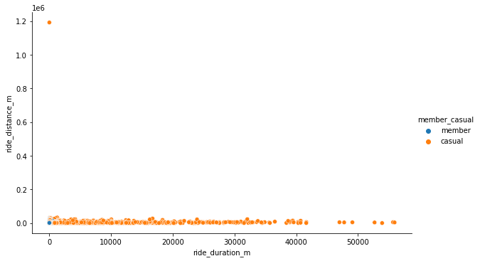

```python
_member_casual = bikeshare_data['member_casual'].unique()

seaborn.relplot(data=bikeshare_data, x='ride_duration_m', y='ride_distance_m', hue='member_casual', hue_order=_member_casual, aspect=1.61)
plt.show()
```

We can observe how one outliner data can skew our plot and made it harder to analyse.  
This outliner data can be treated as a rare case and removed by dropping any ride record that is farther than 10,000m (10km).

```python
bikeshare_data.drop(bikeshare_data[bikeshare_data['ride_distance_m'] > 10000].index, inplace = True)
```

We then can generate a similar plot that spread evenly.

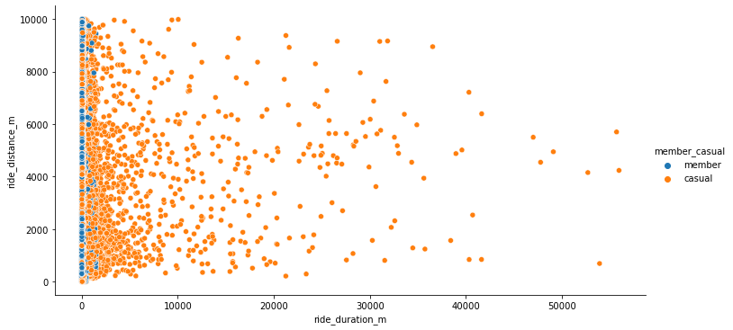

```python
_member_casual = bikeshare_data['member_casual'].unique()

seaborn.relplot(data=bikeshare_data, x='ride_duration_m', y='ride_distance_m', hue='member_casual', hue_order=_member_casual, aspect=2)
plt.show()
```

We can observe from the visualisation above that even though both member and casual riders ride in an approximately equal distance, compared to members, casual riders tend to spent more time on a ride with a huge margin. This could happen to how most casual riders are a one-time recreational rider while members tends to use this as a method to commute and have a set destination or purpose for their rides. Another possibility is how casual riders are not very used with how the bikeshare works and had no idea how to to tell the system they finished with a ride thus making the counter keeps going on.

#### Riding pattern by day of the week

We can use the **week_of_day** column we created beforehand to see which day of the week most customer started renting the bike. To show the bar chart in the correct day order, we need to order our dataframe by day first and store it in a temporary variable.

```python
sorter = ['Monday', 'Tuesday', 'Wednesday', 'Thursday',  'Friday', 'Saturday', 'Sunday']
df_sorted = bikeshare_data.set_index('day_of_week')
df_sorted.loc[sorter]
```

| day_of_week | ride_id | rideable_type | started_at | ended_at | start_station_id | end_station_id | start_lat | start_lng | end_lat | end_lng | member_casual | ride_duration_m | ride_distance_m |
| --- | --- | --- | --- | --- | --- | --- | --- | --- | --- | --- | --- | --- | --- |
| Monday | 6C992BD37A98A63F | classic_bike | 2021-04-12 18:25:36 | 2021-04-12 18:56:55 | TA1307000061 | 13235 | 41.897448 | -87.628722 | 41.948150 | -87.663940 | member | 31 | 6344.197508 |
| Monday | EF150999D6799927 | electric_bike | 2021-04-26 15:19:08 | 2021-04-26 15:47:33 | 20121 | 20121 | 41.741543 | -87.658374 | 41.741551 | -87.658406 | casual | 28 | 2.760997 |
| Monday | A1250C4C180BDB7A | electric_bike | 2021-04-12 13:28:37 | 2021-04-12 13:43:47 | KA1503000069 | KA1503000069 | 41.805856 | -87.592412 | 41.805850 | -87.592502 | casual | 15 | 7.450422 |
| Monday | 1DFCB9DF65688E01 | classic_bike | 2021-04-26 18:25:44 | 2021-04-26 19:06:54 | TA1307000061 | 13235 | 41.897448 | -87.628722 | 41.948150 | -87.663940 | casual | 41 | 6344.197508 |
| Monday | DC85482CC67F4186 | classic_bike | 2021-04-12 10:06:25 | 2021-04-12 10:27:45 | 13133 | 13235 | 41.915983 | -87.677335 | 41.948150 | -87.663940 | casual | 21 | 3741.592569 |
| ... | ... | ... | ... | ... | ... | ... | ... | ... | ... | ... | ... | ... | ... |
| Sunday | 48603383915C7D35 | electric_bike | 2022-03-13 11:15:39 | 2022-03-13 11:24:57 | 13256 | 13221 | 41.903034 | -87.697586 | 41.907655 | -87.672552 | casual | 9 | 2139.590113 |
| Sunday | AA772A0EFB695836 | classic_bike | 2022-03-06 12:21:34 | 2022-03-06 12:35:48 | 637 | 13221 | 41.895634 | -87.672069 | 41.907655 | -87.672552 | casual | 14 | 1335.790372 |
| Sunday | 91F1988CB8EF50C7 | classic_bike | 2022-03-06 12:20:27 | 2022-03-06 12:34:52 | 637 | 13221 | 41.895634 | -87.672069 | 41.907655 | -87.672552 | casual | 14 | 1335.790372 |
| Sunday | D0CA3A1CFFF7CAC9 | electric_bike | 2022-03-20 05:43:39 | 2022-03-20 05:49:41 | TA1308000029 | TA1309000008 | 41.886805 | -87.622555 | 41.879434 | -87.635504 | member | 6 | 1351.069987 |
| Sunday | E23BE3DB740BE3B4 | docked_bike | 2022-03-13 16:31:03 | 2022-03-13 16:39:32 | 13042 | 13022 | 41.900960 | -87.623777 | 41.892278 | -87.612043 | casual | 8 | 1370.434129 |

4326423 rows × 13 columns

After we have ordered our dataframe by day, we can generate a bar graph for it.

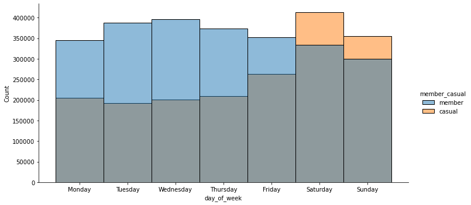

```python
seaborn.displot(data=df_sorted.loc[sorter],
                x="day_of_week", hue='member_casual', hue_order=_member_casual, aspect=2)
```

#### Rideable Type for Each Rider Type

We can calculate the number of rider who choose each rideable type from both rider category by:

```python
bikeshare_data.groupby(['rideable_type','member_casual']).size()
```

```
rideable_type  member_casual
classic_bike   casual           1125331
               member           1896355
docked_bike    casual            238230
electric_bike  casual            476038
               member            590469
dtype: int64
```

## Conclusion and Recommendation

Based on our analysis, we can conclude that Casual riders tend to spend more time on a ride compared to members. This could happen because they mostly use bike sharing for "recreational" purposes which can be supported by how their usage peaked in weekend. In comparison to members who opted for the annual plan due to an habitual need and mostly have a "purposeful" trip.

Based on those findings, Our recommendation to maximize members are:

- Offer a free try-out period for casual riders to use the service in weekday. This will encourage casual riders to try using the bikesharing even for their "purposeful" trip and if they find this option is useful, they can subscribe to the annual plan and become a member.
- Offer a weekend-only annual plan which will attract a casual riders who can not use the service in weekday. This may be beneficial for those who has to commute to work but prefer using bike for working out or as a mode of transportation in weekend.